# EasyVisa_final

#### Tuning Adaboost model with original data

##### Parameter tuning using RandomSearchCV

```
Fitting 5 folds for each of 50 candidates, totalling 250 fits


Model: AdaBoostClassifier

Search Type: random

Best Parameters:
   Hyperparameter  Value
0   n_estimators 50.000
1  learning_rate  0.050
2      estimator    NaN


Training metrics:
   Accuracy  Recall  Precision    F1
0     0.690   0.972      0.690 0.808

Validation metrics:
   Accuracy  Recall  Precision    F1
0     0.694   0.971      0.693 0.809

Confusion Matrix:
CPU times: user 4.21 s, sys: 1.24 s, total: 5.44 s
Wall time: 1min 24s
```

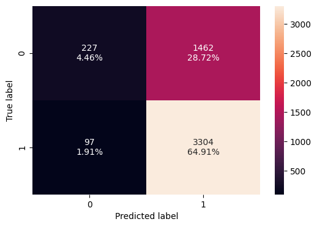

```python
%%time

# defining model
model = AdaBoostClassifier(random_state=1)

# Parameter grid to pass in RandomSearchCV

param_grid = {
    "n_estimators": np.arange(10, 60, 10),  # Number of weak learners (trees) to use
    "learning_rate": [0.01, 0.05, 0.1, 0.2, 0.5, 1],  # Shrinks the contribution of each tree
    "estimator": [
        DecisionTreeClassifier(max_depth=1, random_state=1),  # Stump (default)
        DecisionTreeClassifier(max_depth=2, random_state=1),  # Slightly deeper tree
        DecisionTreeClassifier(max_depth=3, random_state=1),  # Deeper tree for more complex patterns
        None,  # Use the default weak learner (decision stumps)
    ],
}

# Type of scoring used to compare parameter combinations
scorer = metrics.make_scorer(metrics.recall_score)

# Run and display results
tuned_adb1, adb1_train, adb1_val = run_and_display_results(
    model=model,
    param_grid=param_grid,
    X_train=X_train,
    y_train=y_train,
    X_val=X_val,
    y_val=y_val,
    search_type='random',
    scoring=scorer,
    cv=5
)
```

##### Parameter tuning using GridSearchCV

```
Fitting 5 folds for each of 120 candidates, totalling 600 fits


Model: AdaBoostClassifier

Search Type: grid

Best Parameters:
   Hyperparameter                                              Value
0      estimator  DecisionTreeClassifier(max_depth=1, random_sta...
1  learning_rate                                              0.050
2   n_estimators                                                 50


Training metrics:
   Accuracy  Recall  Precision    F1
0     0.690   0.972      0.690 0.808

Validation metrics:
   Accuracy  Recall  Precision    F1
0     0.694   0.971      0.693 0.809

Confusion Matrix:
```

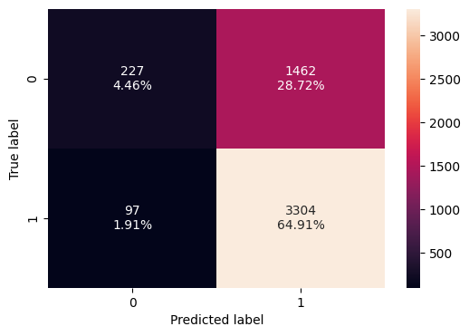

```python
# Defining the model
model = AdaBoostClassifier(random_state=1)

param_grid = {
    "n_estimators": [10,20,30,40,50],  # Number of weak learners (trees) to use
    "learning_rate": [0.01, 0.05, 0.1, 0.2, 0.5, 1],  # Shrinks the contribution of each tree
    "estimator": [
        DecisionTreeClassifier(max_depth=1, random_state=1),  # Stump (default)
        DecisionTreeClassifier(max_depth=2, random_state=1),  # Slightly deeper tree
        DecisionTreeClassifier(max_depth=3, random_state=1),  # Deeper tree for more complex patterns
        None,  # Use the default weak learner (decision stumps)
    ],
}

# Type of scoring used to compare parameter combinations
scorer = metrics.make_scorer(metrics.recall_score)

# Run and display results
tuned_adb2, adb2_train, adb2_val = run_and_display_results(
    model=model,
    param_grid=param_grid,
    X_train=X_train,
    y_train=y_train,
    X_val=X_val,
    y_val=y_val,
    search_type='grid',
    scoring=scorer,
    cv=5
)
```

#### Tuning Adaboost with Oversampled data

##### Parameter tuning using RandomSearchCV

```
Fitting 5 folds for each of 50 candidates, totalling 250 fits


Model: AdaBoostClassifier

Search Type: random

Best Parameters:
   Hyperparameter  Value
0   n_estimators 10.000
1  learning_rate  0.050
2      estimator    NaN


Training metrics:
   Accuracy  Recall  Precision    F1
0     0.647   0.931      0.593 0.725

Validation metrics:
   Accuracy  Recall  Precision    F1
0     0.710   0.933      0.717 0.811

Confusion Matrix:
CPU times: user 2.46 s, sys: 1.9 s, total: 4.36 s
Wall time: 1min 5s
```

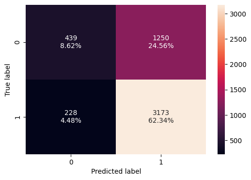

```python
%%time

# defining model
Model = AdaBoostClassifier(random_state=1)

# Parameter grid to pass in RandomSearchCV

param_grid = {
    "n_estimators": np.arange(10, 60, 10),  # Number of weak learners (trees) to use
    "learning_rate": [0.01, 0.05, 0.1, 0.2, 0.5, 1],  # Shrinks the contribution of each tree
    "estimator": [
        DecisionTreeClassifier(max_depth=1, random_state=1),  # Stump (default)
        DecisionTreeClassifier(max_depth=2, random_state=1),  # Slightly deeper tree
        DecisionTreeClassifier(max_depth=3, random_state=1),  # Deeper tree for more complex patterns
        None,  # Use the default weak learner (decision stumps)
    ],
}

# Type of scoring used to compare parameter combinations
scorer = metrics.make_scorer(metrics.recall_score)

# Run and display results
tuned_adb3, adb3_train, adb3_val = run_and_display_results(
    model=model,
    param_grid=param_grid,
    X_train=X_train_over,
    y_train=y_train_over,
    X_val=X_val,
    y_val=y_val,
    search_type='random',
    scoring=scorer,
    cv=5
)
```

##### Parameter tuning using GridSearchCV

```
Fitting 5 folds for each of 120 candidates, totalling 600 fits


Model: AdaBoostClassifier

Search Type: grid

Best Parameters:
   Hyperparameter                                              Value
0      estimator  DecisionTreeClassifier(max_depth=1, random_sta...
1  learning_rate                                              0.010
2   n_estimators                                                 10


Training metrics:
   Accuracy  Recall  Precision    F1
0     0.647   0.931      0.593 0.725

Validation metrics:
   Accuracy  Recall  Precision    F1
0     0.710   0.933      0.717 0.811

Confusion Matrix:
```

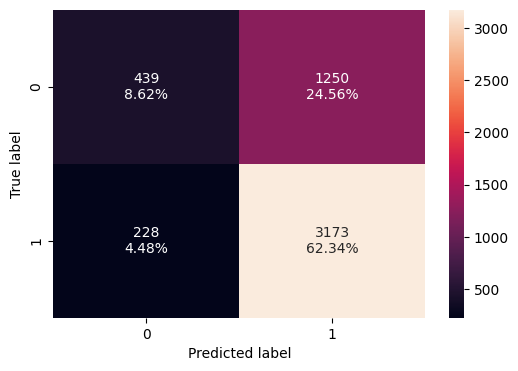

```python
# Defining the model
model = AdaBoostClassifier(random_state=1)

param_grid = {
    "n_estimators": [10,20,30,40,50],  # Number of weak learners (trees) to use
    "learning_rate": [0.01, 0.05, 0.1, 0.2, 0.5, 1],  # Shrinks the contribution of each tree
    "estimator": [
        DecisionTreeClassifier(max_depth=1, random_state=1),  # Stump (default)
        DecisionTreeClassifier(max_depth=2, random_state=1),  # Slightly deeper tree
        DecisionTreeClassifier(max_depth=3, random_state=1),  # Deeper tree for more complex patterns
        None,  # Use the default weak learner (decision stumps)
    ],
}

# Type of scoring used to compare parameter combinations
scorer = metrics.make_scorer(metrics.recall_score)

# Run and display results
tuned_adb4, adb4_train, adb4_val = run_and_display_results(
    model=model,
    param_grid=param_grid,
    X_train=X_train_over,
    y_train=y_train_over,
    X_val=X_val,
    y_val=y_val,
    search_type='grid',
    scoring=scorer,
    cv=5
)
```

#### Tuning XGBoost using oversampled data

##### Parameter tuning using RandomSearchCV

```
Fitting 5 folds for each of 50 candidates, totalling 250 fits


Model: XGBClassifier

Search Type: random

Best Parameters:
      Hyperparameter  Value
0         subsample  0.900
1  scale_pos_weight  5.000
2        reg_lambda 10.000
3      n_estimators 50.000
4         max_depth  3.000
5     learning_rate  0.010
6             gamma  3.000


Training metrics:
   Accuracy  Recall  Precision    F1
0     0.659   1.000      0.595 0.746

Validation metrics:
   Accuracy  Recall  Precision    F1
0     0.668   1.000      0.668 0.801

Confusion Matrix:
CPU times: user 4.13 s, sys: 2.14 s, total: 6.27 s
Wall time: 12.2 s
```

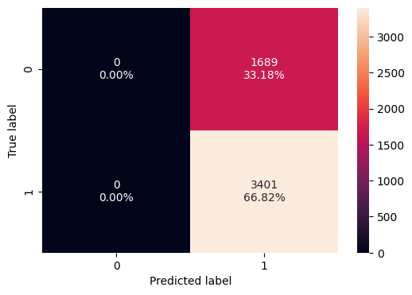

```python
%%time

# defining model
model = XGBClassifier(random_state=1,eval_metric='logloss')

# Parameter grid to pass in RandomSearchCV

# Parameter grid to pass in RandomizedSearchCV
param_grid={'n_estimators':np.arange(50,150,50),
            'scale_pos_weight':[2,5,10],
            'learning_rate':[0.01,0.1,0.2,0.05],
            'gamma':[0,1,3,5],
            'subsample':[0.8,0.9,1],
            'max_depth':np.arange(1,5,1),
            'reg_lambda':[5,10]}

# Type of scoring used to compare parameter combinations
scorer = metrics.make_scorer(metrics.recall_score)

# Run and display results
tuned_xgb1, xgb1_train, xgb1_val = run_and_display_results(
    model=model,
    param_grid=param_grid,
    X_train=X_train_over,
    y_train=y_train_over,
    X_val=X_val,
    y_val=y_val,
    search_type='random',
    scoring=scorer,
    cv=5
)
```

##### Parameter tuning using GridSearchCV

```
Fitting 5 folds for each of 864 candidates, totalling 4320 fits


Model: XGBClassifier

Search Type: grid

Best Parameters:
      Hyperparameter  Value
0             gamma  3.000
1     learning_rate  0.010
2         max_depth  1.000
3      n_estimators 50.000
4        reg_lambda  5.000
5  scale_pos_weight  2.000
6         subsample  0.800


Training metrics:
   Accuracy  Recall  Precision    F1
0     0.500   1.000      0.500 0.667

Validation metrics:
   Accuracy  Recall  Precision    F1
0     0.668   1.000      0.668 0.801

Confusion Matrix:
```

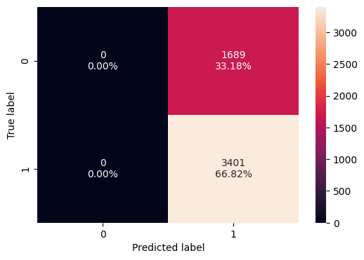

```python
# Defining the model
model = XGBClassifier(random_state=1,eval_metric='logloss')

#Parameter grid to pass in GridSearchCV
param_grid={'n_estimators':[50,100,150],
            'scale_pos_weight':[2,5,10],
            'learning_rate':[0.01,0.1,0.2,0.05],
            'gamma':[3,5],
            'subsample':[0.8,0.9,1],
            'max_depth':[1,3],
            'reg_lambda':[5,10]}

# Type of scoring used to compare parameter combinations
scorer = metrics.make_scorer(metrics.recall_score)

# Run and display results
tuned_xgb2, xgb2_train, xgb2_val = run_and_display_results(
    model=model,
    param_grid=param_grid,
    X_train=X_train_over,
    y_train=y_train_over,
    X_val=X_val,
    y_val=y_val,
    search_type='grid',
    scoring=scorer,
    cv=5
)
```

#### Model Comparison and Final Model Selection

##### Model Comparison

```python
# training performance comparison

models_train_comp_df = pd.concat(
    [
        gbm1_train.T,
        gbm2_train.T,
        gbm3_train.T,
        gbm4_train.T,
        adb1_train.T,
        adb2_train.T,
        adb3_train.T,
        adb4_train.T,
        xgb1_train.T,
        xgb2_train.T
    ],
    axis=1,
)
models_train_comp_df.columns = [
    "Gradient boosting trained with Original data (RandomSearchCV)",
    "Gradient boosting trained with Original data (GridSearchCV)",
    "Gradient boosting trained with Oversampled data (RandomSearchCV)",
    "Gradient boosting trained with Oversampled data (GridSearchCV)",
    "AdaBoost trained with Original data (RandomSearchCV)",
    "AdaBoost trained with Original data (GridSearchCV)",
    "AdaBoost trained with Oversampled data (RandomSearchCV)",
    "AdaBoost trained with Oversampled data (GridSearchCV)",
    "XGBoost trained with Oversampled data (RandomSearchCV)",
    "XGBoost trained with Oversampled data (GridSearchCV)"
]
print("Training performance comparison:")
models_train_comp_df
```

```
Training performance comparison:
```

|  | Gradient boosting trained with Original data (RandomSearchCV) | Gradient boosting trained with Original data (GridSearchCV) | Gradient boosting trained with Oversampled data (RandomSearchCV) | Gradient boosting trained with Oversampled data (GridSearchCV) | AdaBoost trained with Original data (RandomSearchCV) | AdaBoost trained with Original data (GridSearchCV) | AdaBoost trained with Oversampled data (RandomSearchCV) | AdaBoost trained with Oversampled data (GridSearchCV) | XGBoost trained with Oversampled data (RandomSearchCV) | XGBoost trained with Oversampled data (GridSearchCV) |
| --- | --- | --- | --- | --- | --- | --- | --- | --- | --- | --- |
| Accuracy | 0.722 | 0.720 | 0.797 | 0.795 | 0.690 | 0.690 | 0.647 | 0.647 | 0.659 | 0.500 |
| Recall | 0.938 | 0.939 | 0.857 | 0.866 | 0.972 | 0.972 | 0.931 | 0.931 | 1.000 | 1.000 |
| Precision | 0.726 | 0.724 | 0.765 | 0.758 | 0.690 | 0.690 | 0.593 | 0.593 | 0.595 | 0.500 |
| F1 | 0.818 | 0.818 | 0.808 | 0.808 | 0.808 | 0.808 | 0.725 | 0.725 | 0.746 | 0.667 |

```python
# Validation performance comparison

models_val_comp_df = pd.concat(
    [
        gbm1_val.T,
        gbm2_val.T,
        gbm3_val.T,
        gbm4_val.T,
        adb1_val.T,
        adb2_val.T,
        adb3_val.T,
        adb4_val.T,
        xgb1_val.T,
        xgb2_val.T
    ], axis=1,
)
models_val_comp_df.columns = [
    "Gradient boosting trained with Original data (RandomSearchCV)",
    "Gradient boosting trained with Original data (GridSearchCV)",
    "Gradient boosting trained with Oversampled data (RandomSearchCV)",
    "Gradient boosting trained with Oversampled data (GridSearchCV)",
    "AdaBoost trained with Original data (RandomSearchCV)",
    "AdaBoost trained with Original data (GridSearchCV)",
    "AdaBoost trained with Oversampled data (RandomSearchCV)",
    "AdaBoost trained with Oversampled data (GridSearchCV)",
    "XGBoost trained with Oversampled data (RandomSearchCV)",
    "XGBoost trained with Oversampled data (GridSearchCV)"
]
print("Validation performance comparison:")
models_val_comp_df
```

```
Validation performance comparison:
```

|  | Gradient boosting trained with Original data (RandomSearchCV) | Gradient boosting trained with Original data (GridSearchCV) | Gradient boosting trained with Oversampled data (RandomSearchCV) | Gradient boosting trained with Oversampled data (GridSearchCV) | AdaBoost trained with Original data (RandomSearchCV) | AdaBoost trained with Original data (GridSearchCV) | AdaBoost trained with Oversampled data (RandomSearchCV) | AdaBoost trained with Oversampled data (GridSearchCV) | XGBoost trained with Oversampled data (RandomSearchCV) | XGBoost trained with Oversampled data (GridSearchCV) |
| --- | --- | --- | --- | --- | --- | --- | --- | --- | --- | --- |
| Accuracy | 0.723 | 0.721 | 0.740 | 0.743 | 0.694 | 0.694 | 0.710 | 0.710 | 0.668 | 0.668 |
| Recall | 0.938 | 0.938 | 0.859 | 0.874 | 0.971 | 0.971 | 0.933 | 0.933 | 1.000 | 1.000 |
| Precision | 0.727 | 0.725 | 0.775 | 0.771 | 0.693 | 0.693 | 0.717 | 0.717 | 0.668 | 0.668 |
| F1 | 0.819 | 0.818 | 0.815 | 0.820 | 0.809 | 0.809 | 0.811 | 0.811 | 0.801 | 0.801 |

- GBM model, Adaboost model trained on original data and XGBoost model trained on oversampled data are performing well.
- Since we wanted to maximize recall, we will chose XGBoost trained on oversampled data.

##### Final Model

```python
# Let's check the performance on test set
xgb_test = model_performance_classification_sklearn(tuned_xgb1, X_test, y_test)
xgb_test
```

|  | Accuracy | Recall | Precision | F1 |
| --- | --- | --- | --- | --- |
| 0 | 0.668 | 1.000 | 0.668 | 0.801 |

### Feature Importance

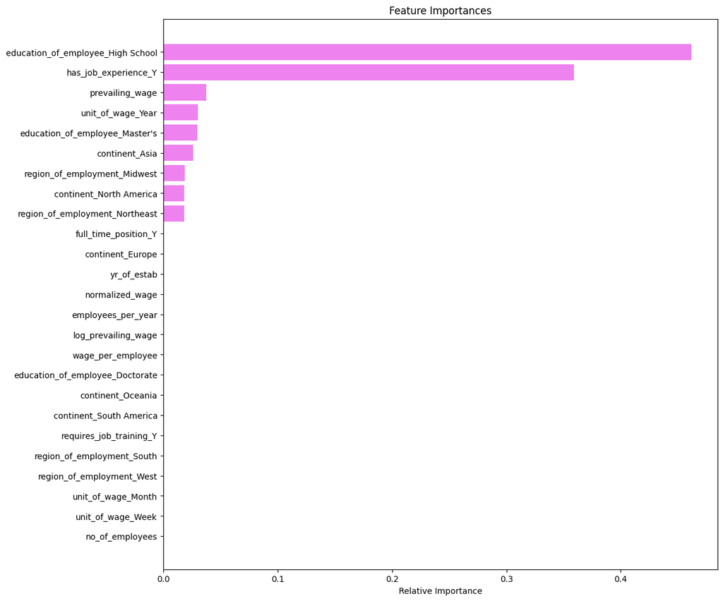

```python
feature_names = X_train.columns
importances = tuned_xgb1.feature_importances_
indices = np.argsort(importances)

plt.figure(figsize=(12, 12))
plt.title("Feature Importances")
plt.barh(range(len(indices)), importances[indices], color="violet", align="center")
plt.yticks(range(len(indices)), [feature_names[i] for i in indices])
plt.xlabel("Relative Importance")
plt.show()
```

- education_of_employee_High School is most important feature, indicating that education level significantly impacts the model's predictions. High school education likely plays a key role in determining case outcomes.
- has_job_experience_Y is the second most important feature, suggesting that prior job experience strongly influences the likelihood of certification.
- Wage-related features play a moderate role, suggesting that financial aspects are considered but are not the primary drivers.
- Geographic and engineered features have limited impact, indicating that the model relies more on individual-level attributes than organizational or regional factors.

## Conclusion and Insights

### Key Takeaways from Model and Data Analysis

### 1. Education Level is the most significant predictor of visa approval

**Recommendation**: Focus on prioritizing applications from candidates with High School education during the initial screening process.

### 2. Job Experience strongly correlates with visa approval

- Candidates with prior job experience (`has_job_experience_Y`) are significantly more likely to have their applications approved.
- Lack of job experience reduces the likelihood of approval.

**Recommendation**: Prioritize applications from candidates with relevant job experience.

### 3. Wage-related attributes moderately impact approval likelihood

- `Prevailing wage` and `unit of wage (Year)` are moderately important predictors.
- Higher wages correlate with better approval chances, but they are secondary to education and job experience.

**Recommendation**: Use wage-related attributes as supplementary criteria for prioritization. Highlight applications with competitive wages during the evaluation process.

### 4. Geographic attributes have limited influence

- Features like `region of employment` and `continent` have limited impact on approval likelihood.
- These factors are less critical compared to individual-level attributes like education and job experience.

**Recommendation**: Deprioritize geographic attributes during the evaluation process to streamline decision-making.

### 6. Engineered features have limited predictive power

- Features like employees_per_year, log_prevailing_wage, and wage_per_employee have low importance in the model.
- These features do not significantly improve predictive accuracy.

**Recommendation**: Avoid relying heavily on engineered features for decision-making. Focus on core attributes like education and job experience.

### 7. Automated Candidate Shortlisting can reduce workload

- The best-performing model (e.g., XGBoost) can be used to automate the scoring and ranking of candidates based on their likelihood of approval.
- This will help visa offices prioritize high-probability applications and reduce manual workload.

**Recommendation**: Implement an automated scoring system to rank candidates based on approval likelihood. Use this system to streamline the evaluation process and focus resources on high-priority applications.